# Students Performance Factors

José Medina

# Análisis del Rendimiento Académico

## Introducción

En este estudio, analizamos los factores que influyen en el rendimiento académico de los estudiantes, centrándonos en dos aspectos clave:

1. **Estrategias de estudio para estudiantes con dificultades de aprendizaje**: Evaluamos si la relación entre horas de estudio y rendimiento es distinta para estudiantes con y sin discapacidades de aprendizaje, así como la influencia de factores como la motivación, la asistencia y las tutorías.
2. **Impacto del sueño y el estudio en el rendimiento académico**: Analizamos cómo la combinación de horas de sueño y estudio afecta el rendimiento, identificando el equilibrio óptimo entre ambas variables.

Utilizaremos modelos estadísticos de regresión y análisis de superficie de respuesta para interpretar los datos y extraer conclusiones fundamentadas.

Para contestar estas 2 preguntas, se usará el csv con los datos limpios extraido de la parte global.

```r
# Cargar datos limpiados
df <- read.csv("data/df_cleaned.csv")
```

# Pregunta 1: ¿La relación de horas de estudio y redimiento es distinta para estudiantes con descacidades de aprendizaje?

Este estudio investiga si los estudiantes con dificultades de aprendizaje requieren estrategias de estudio diferentes para alcanzar el mismo nivel de desempeño que sus compañeros sin discapacidades. Específicamente, analizaremos:

1. **Si la relación entre horas de estudio y rendimiento es distinta para estudiantes con y sin discapacidades de aprendizaje.**
2. **Si otros factores como la motivación, las tutorías y la asistencia tienen un mayor impacto en el desempeño de los estudiantes con dificultades de aprendizaje.**

Para ello, utilizaremos modelos de regresión con interacciones y evaluaremos la importancia de diferentes factores en el rendimiento académico.

## Comparación de la relación entre horas de estudio y rendimiento según dificultades de aprendizaje

Para evaluar si la relación entre horas de estudio y rendimiento varía entre estudiantes con y sin dificultades de aprendizaje, ajustamos un modelo de regresión con interacción.

```r
library(ggplot2)
library(dplyr)
library(lme4)

# Crear directorio para guardar imágenes
if (!dir.exists("individual_JoseMedina_files")) {
  dir.create("individual_JoseMedina_files")
}

# Ajustar modelo de regresión con interacción
modelo_interaccion <- lm(Exam_Score ~ Hours_Studied * Learning_Disabilities, data=df)
summary(modelo_interaccion)
```

```
Call:
lm(formula = Exam_Score ~ Hours_Studied * Learning_Disabilities,
    data = df)

Residuals:
   Min     1Q Median     3Q    Max
-8.632 -2.247 -0.209  1.945 33.368

Coefficients:
                                     Estimate Std. Error t value Pr(>|t|)
(Intercept)                         61.593212   0.160708 383.263  < 2e-16 ***
Hours_Studied                        0.288472   0.007694  37.493  < 2e-16 ***
Learning_Disabilities               -1.367440   0.504704  -2.709  0.00676 **
Hours_Studied:Learning_Disabilities  0.018931   0.024498   0.773  0.43970
---
Signif. codes:  0 ‘***’ 0.001 ‘**’ 0.01 ‘*’ 0.05 ‘.’ 0.1 ‘ ’ 1

Residual standard error: 3.491 on 6374 degrees of freedom
Multiple R-squared:  0.2043,    Adjusted R-squared:  0.204
F-statistic: 545.6 on 3 and 6374 DF,  p-value: < 2.2e-16
```

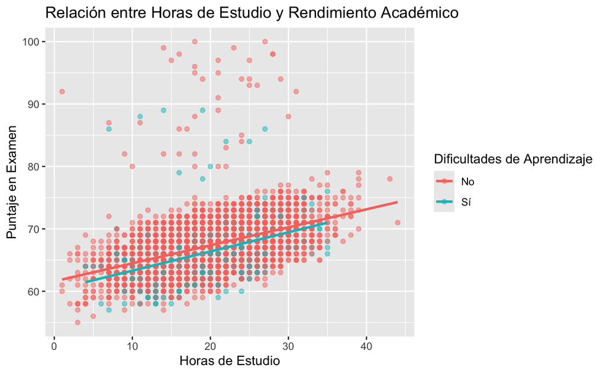

```r
# Modificar la variable para que en lugar de 0 y 1, muestre "No" y "Sí"
df$Learning_Disabilities <- factor(df$Learning_Disabilities, levels = c(0, 1), labels = c("No", "Sí"))

# Guardar y mostrar gráfico de interacción con etiquetas personalizadas
p1 <- ggplot(df, aes(x=Hours_Studied, y=Exam_Score, color=Learning_Disabilities)) +
  geom_point(alpha=0.5) +
  geom_smooth(method="lm", se=FALSE) +
  labs(title="Relación entre Horas de Estudio y Rendimiento Académico",
       x="Horas de Estudio",
       y="Puntaje en Examen",
       color="Dificultades de Aprendizaje")

# Guardar el gráfico
ggsave("individual_JoseMedina_files/interaction_study_disabilities.png", plot=p1, width=8, height=6)

# Mostrar el gráfico
print(p1)
```

### **Conclusión de la Relación entre Horas de Estudio y Rendimiento**

- El coeficiente de interacción entre `Hours_Studied` y `Learning_Disabilities` no es significativo (**p = 0.4397**), lo que indica que el efecto de las horas de estudio sobre el rendimiento académico **no varía de manera considerable** entre estudiantes con y sin dificultades de aprendizaje.
- Sin embargo, el coeficiente de `Learning_Disabilities` es negativo y significativo (**β = -1.367**, **p = 0.00676**), lo que sugiere que los estudiantes con dificultades de aprendizaje tienen, en promedio, un rendimiento académico más bajo en comparación con aquellos sin dificultades.
- La pendiente de la regresión indica que el tiempo de estudio tiene un **impacto positivo en el rendimiento académico**, aunque no hay evidencia estadística de que este impacto sea diferente para los dos grupos.

**Implicación:** Aunque los estudiantes con dificultades de aprendizaje tienen un rendimiento promedio menor, la relación entre estudio y desempeño es similar, lo que sugiere que estrategias de refuerzo académico podrían ayudarlos a cerrar la brecha en su desempeño.

## Evaluación del impacto de otros factores en el rendimiento académico

Además de las horas de estudio, analizamos si otros factores como la **motivación, la asistencia y el acceso a tutorías** influyen en el desempeño de los estudiantes con dificultades de aprendizaje.

```r
modelo_factores <- lm(Exam_Score ~ Hours_Studied + Motivation_Level + Attendance + Tutoring_Sessions + Learning_Disabilities +
                        Motivation_Level * Learning_Disabilities + Attendance * Learning_Disabilities + Tutoring_Sessions * Learning_Disabilities, data=df)

summary(modelo_factores)
```

```
Call:
lm(formula = Exam_Score ~ Hours_Studied + Motivation_Level +
    Attendance + Tutoring_Sessions + Learning_Disabilities +
    Motivation_Level * Learning_Disabilities + Attendance * Learning_Disabilities +
    Tutoring_Sessions * Learning_Disabilities, data = df)

Residuals:
    Min      1Q  Median      3Q     Max
-5.4156 -1.2176 -0.1810  0.8843 31.4645

Coefficients:
                                           Estimate Std. Error t value Pr(>|t|)
(Intercept)                               43.857407   0.280083 156.587   <2e-16 ***
Hours_Studied                              0.294234   0.005342  55.077   <2e-16 ***
Motivation_Level                           0.519074   0.048727  10.653   <2e-16 ***
Attendance                                 0.198540   0.002925  67.874   <2e-16 ***
Tutoring_Sessions                          0.486230   0.027604  17.614   <2e-16 ***
Learning_DisabilitiesSí                    0.644296   0.792056   0.813   0.4160
Motivation_Level:Learning_DisabilitiesSí   0.067676   0.146672   0.461   0.6445
Attendance:Learning_DisabilitiesSí        -0.020741   0.009061  -2.289   0.0221 *
Tutoring_Sessions:Learning_DisabilitiesSí  0.020284   0.080103   0.253   0.8001
---
Signif. codes:  0 ‘***’ 0.001 ‘**’ 0.01 ‘*’ 0.05 ‘.’ 0.1 ‘ ’ 1

Residual standard error: 2.552 on 6369 degrees of freedom
Multiple R-squared:  0.575, Adjusted R-squared:  0.5745
F-statistic:  1077 on 8 and 6369 DF,  p-value: < 2.2e-16
```

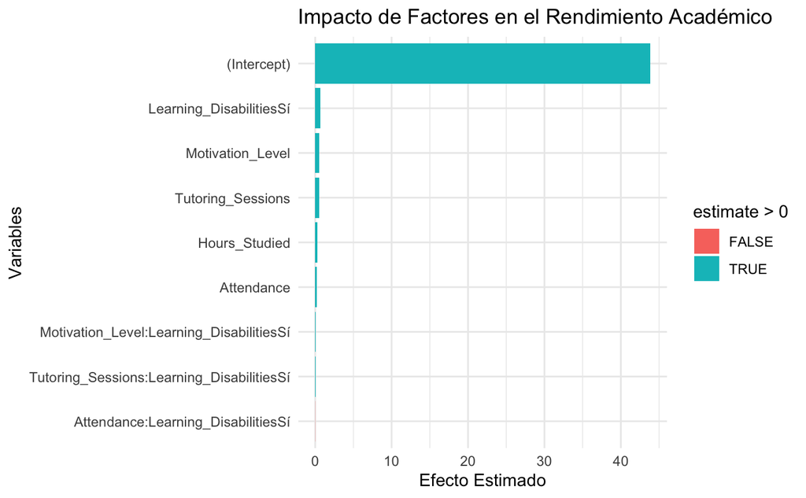

```r
# Guardar y mostrar gráfico de importancia de factores
library(ggplot2)
library(broom)

# Extraer coeficientes del modelo
effects <- tidy(modelo_factores)

p2 <- ggplot(effects, aes(x=reorder(term, estimate), y=estimate, fill=estimate > 0)) +
  geom_col() +
  coord_flip() +
  labs(title="Impacto de Factores en el Rendimiento Académico",
       x="Variables",
       y="Efecto Estimado") +
  theme_minimal()

ggsave("individual_JoseMedina_files/factor_importance.png", plot=p2, width=8, height=6)
print(p2)
```

### **Conclusión sobre el Impacto de Otros Factores**

**Implicación:** La motivación y el acceso a tutorías tienen un impacto clave en el rendimiento de todos los estudiantes, sin importar si tienen dificultades de aprendizaje. Sin embargo, la asistencia a clases parece ser menos determinante para los estudiantes con dificultades de aprendizaje, lo que sugiere que pueden requerir **métodos alternativos de aprendizaje**, como sesiones personalizadas o materiales complementarios.

# Pregunta 2-**¿Cómo afecta la combinación de horas de sueño y estudio al rendimiento académico?**

Este estudio busca analizar cómo la combinación de horas de sueño y estudio afecta el rendimiento académico de los estudiantes. Específicamente, se abordarán los siguientes puntos:

1. **Construir una superficie de respuesta (Response Surface Analysis) para analizar la relación entre horas de sueño, horas de estudio y calificación final.**
2. **Identificar el punto óptimo en el que el equilibrio entre ambas variables maximiza el rendimiento académico.**

## Análisis de la Relación entre Horas de Sueño, Estudio y Rendimiento Académico

Para evaluar la interacción entre el tiempo dedicado al estudio y el descanso, ajustamos un modelo de regresión cuadrática que nos permitirá modelar relaciones no lineales.

```r
library(ggplot2)
library(dplyr)
library(car)

# Cargar datos limpiados
df <- read.csv("data/df_cleaned.csv")

# Crear directorio para guardar imágenes
if (!dir.exists("individual_JoseMedina_files")) {
  dir.create("individual_JoseMedina_files")
}

# Ajustar modelo de regresión cuadrática para estudiar la relación
modelo_superficie <- lm(Exam_Score ~ poly(Hours_Studied, 2) + poly(Sleep_Hours, 2) + Hours_Studied:Sleep_Hours, data=df)
summary(modelo_superficie)
```

```
Call:
lm(formula = Exam_Score ~ poly(Hours_Studied, 2) + poly(Sleep_Hours,
    2) + Hours_Studied:Sleep_Hours, data = df)

Residuals:
   Min     1Q Median     3Q    Max
-8.548 -2.266 -0.133  2.014 33.568

Coefficients:
                            Estimate Std. Error t value Pr(>|t|)
(Intercept)                66.993568   0.692801  96.700  < 2e-16 ***
poly(Hours_Studied, 2)1   133.008096  16.941091   7.851  4.8e-15 ***
poly(Hours_Studied, 2)2     6.357910   3.504214   1.814   0.0697 .
poly(Sleep_Hours, 2)1     -11.550651  12.044860  -0.959   0.3376
poly(Sleep_Hours, 2)2       1.746246   3.504141   0.498   0.6183
Hours_Studied:Sleep_Hours   0.001837   0.004916   0.374   0.7086
---
Signif. codes:  0 ‘***’ 0.001 ‘**’ 0.01 ‘*’ 0.05 ‘.’ 0.1 ‘ ’ 1

Residual standard error: 3.503 on 6372 degrees of freedom
Multiple R-squared:  0.1992,    Adjusted R-squared:  0.1986
F-statistic:   317 on 5 and 6372 DF,  p-value: < 2.2e-16
```

### **Conclusión de la Relación entre Horas de Estudio, Sueño y Rendimiento Académico**

- **El coeficiente del término cuadrático de `Hours_Studied` no es significativo** (**p = 0.0697**), lo que indica que la relación entre las horas de estudio y el rendimiento académico **es esencialmente lineal** con una ligera tendencia no lineal que no es estadísticamente fuerte.
- **Los coeficientes de `poly(Sleep_Hours, 2)` no son significativos** (**p = 0.3376 y p = 0.6183**), lo que sugiere que **las horas de sueño no tienen un impacto fuerte en el rendimiento** según este modelo.
- **La interacción entre horas de sueño y horas de estudio (`Hours_Studied:Sleep_Hours`) tampoco es significativa** (**p = 0.7086**), lo que indica que **no hay una combinación específica de estudio y sueño que genere un efecto notable en el rendimiento académico**.
- A pesar de la falta de significancia en algunos coeficientes, el modelo sigue explicando una parte del rendimiento académico (**R² ajustado = 0.1986**), lo que indica que estas variables tienen cierta relación con la calificación final, pero no de una manera completamente determinante.

**Implicación:** No se observa una interacción clara entre las horas de estudio y las horas de sueño en términos de su impacto en el rendimiento académico. Esto sugiere que **otros factores pueden jugar un papel más importante en la determinación del rendimiento**.

## Visualización de la Superficie de Respuesta

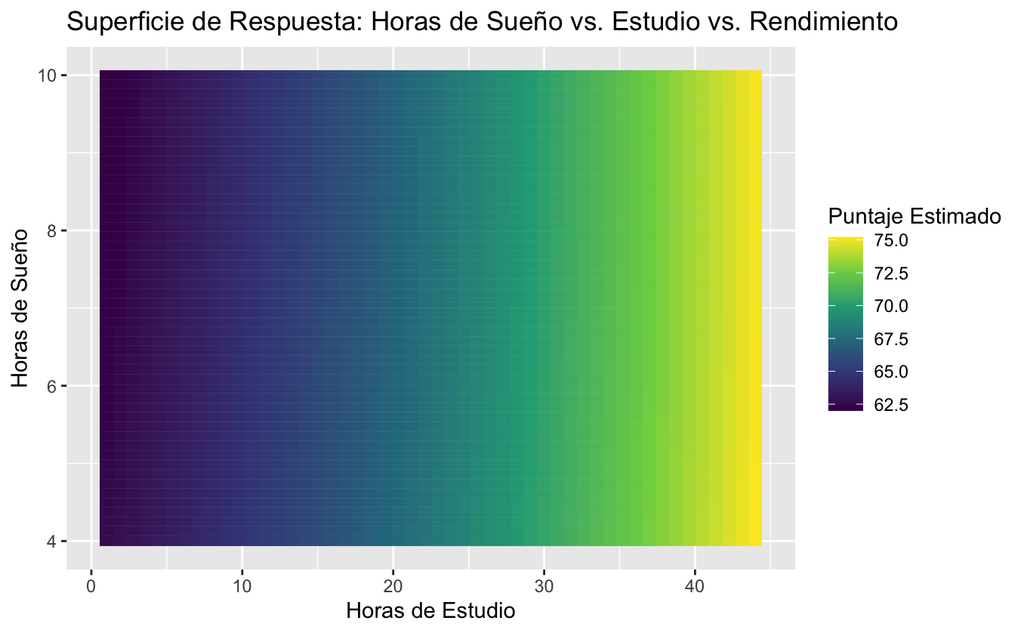

```r
library(ggplot2)
library(reshape2)

# Generar datos para la superficie
grid <- expand.grid(
  Hours_Studied = seq(min(df$Hours_Studied), max(df$Hours_Studied), length.out=50),
  Sleep_Hours = seq(min(df$Sleep_Hours), max(df$Sleep_Hours), length.out=50)
)
grid$Predicted_Score <- predict(modelo_superficie, newdata=grid)

# Crear gráfico 2D de la superficie de respuesta
p_surface <- ggplot(grid, aes(x=Hours_Studied, y=Sleep_Hours, fill=Predicted_Score)) +
  geom_tile() +
  scale_fill_viridis_c() +
  labs(title="Superficie de Respuesta: Horas de Sueño vs. Estudio vs. Rendimiento",
       x="Horas de Estudio",
       y="Horas de Sueño",
       fill="Puntaje Estimado")

ggsave("individual_JoseMedina_files/response_surface.png", plot=p_surface, width=8, height=6)
print(p_surface)
```

## Identificación del Punto Óptimo

Finalmente, identificamos la combinación de horas de estudio y sueño que maximiza el rendimiento académico.

```r
# Encontrar combinación óptima
optimal_index <- which.max(grid$Predicted_Score)
optimal_values <- grid[optimal_index, ]
optimal_values
```

|  | Hours_Studied | Sleep_Hours | Predicted_Score |
| --- | --- | --- | --- |
| 50 | 44 | 4 | 75.20429 |

## **Conclusión General**

**Recomendación:** En lugar de centrarse únicamente en el número de horas dedicadas al estudio y al sueño, es importante fomentar estrategias de estudio eficientes, descanso adecuado y manejo del tiempo para optimizar el rendimiento académico de los estudiantes.